# Reproducible Research: Peer Assessment 1

## Loading and preprocessing the data

1. Code for reading in the dataset and/or processing the data

```r
library(readr)
library(ggplot2)
library(dplyr)
activityFrame <- read_csv("./activity.zip")
# convert the interval column to a set of factors
activityFrame$interval <- factor(activityFrame$interval)
```

## What is mean total number of steps taken per day?

### Total steps per day:

```r
dailySteps <- activityFrame %>% group_by(date) %>% summarize(dailyTotal = sum(steps, na.rm = TRUE))
print(dailySteps)
```

```
## # A tibble: 61 x 2
##    date       dailyTotal
##    <date>          <dbl>
##  1 2012-10-01          0
##  2 2012-10-02        126
##  3 2012-10-03      11352
##  4 2012-10-04      12116
##  5 2012-10-05      13294
##  6 2012-10-06      15420
##  7 2012-10-07      11015
##  8 2012-10-08          0
##  9 2012-10-09      12811
## 10 2012-10-10       9900
## # ... with 51 more rows
```

### Histogram showing total steps per day

2. Histogram of the total number of steps taken each day

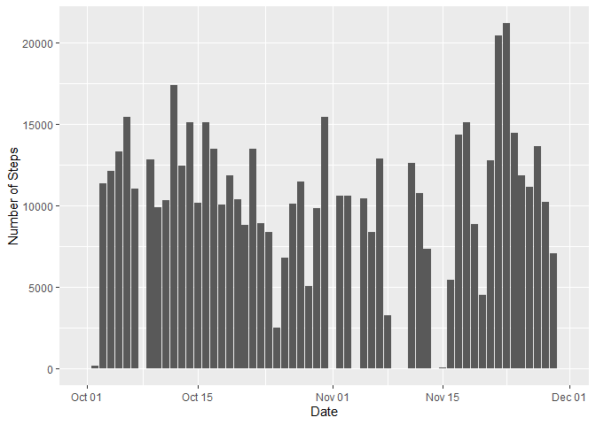

```r
ggplot(dailySteps, aes(x = as.Date(date, format = "%y-%m-%d"), y = dailyTotal)) +
  geom_bar(stat = "identity") +
  labs(x = "Date", y = "Number of Steps")
```

### Mean number of steps per day

3a. Mean number of steps taken each day

```r
averageStepsPerDay <- mean(dailySteps$dailyTotal)
print(averageStepsPerDay)
```

```
## [1] 9354.23
```

### Median number of steps per day

3b. Median number of steps taken each day

```r
medianStepsPerDay <- median(dailySteps$dailyTotal)
print(medianStepsPerDay)
```

```
## [1] 10395
```

## What is the average daily activity pattern?

### Time series plot of average number of steps taken across all days for each interval

4. Time series plot of the average number of steps taken

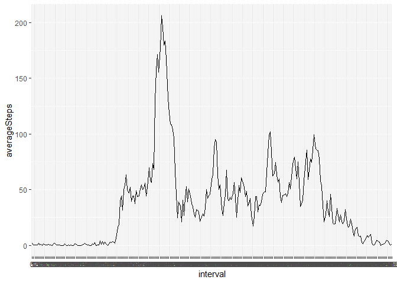

```r
intervalAverageSteps <- activityFrame %>% group_by(interval) %>% summarize(averageSteps = mean(steps, na.rm = TRUE))
ggplot(intervalAverageSteps, aes(x = interval, y = averageSteps, group = 1)) + geom_line()
```

### Time of day that contains the most number of steps (on average)

5. The 5-minute interval that, on average, contains the maximum number of steps

```r
sortedStepsAverage <- arrange(intervalAverageSteps, desc(averageSteps))
print(as.character(sortedStepsAverage$interval[[1]]))
```

```
## [1] "835"
```

## Imputing missing values

### Total number of missing values in dataset

```r
sum(is.na(activityFrame$steps))
```

```
## [1] 2304
```

### Fill in missing values

6. Code to describe and show a strategy for imputing missing data

Will fill in missing values with the average for that interval as calculated earlier in #4

```r
# create a copy of the frame to store the imputed values
imputedActivityFrame <- data.frame(activityFrame)
numberOfRecords <- nrow(imputedActivityFrame)
for(index in 1:numberOfRecords) {
    # if the current row contains missing data for the number of steps, let's fix that
    if(is.na(imputedActivityFrame$steps[index])) {
        # get the current interval
        intervalValue <- imputedActivityFrame$interval[index]
        # get the index into the intervalAverageSteps table
        averageIntervalIndex <- which(intervalAverageSteps$interval == intervalValue)
        # get the average steps for the interval
        averageValue <- intervalAverageSteps$averageSteps[averageIntervalIndex]
        # need to change the NA to the average value of the interval
        imputedActivityFrame$steps[index] <- averageValue
    }
}

print(head(imputedActivityFrame))
```

```
##       steps       date interval
## 1 1.7169811 2012-10-01        0
## 2 0.3396226 2012-10-01        5
## 3 0.1320755 2012-10-01       10
## 4 0.1509434 2012-10-01       15
## 5 0.0754717 2012-10-01       20
## 6 2.0943396 2012-10-01       25
```

### Histogram of total steps taken each day (imputed data)

7. Histogram of the total number of steps taken each day after missing values are imputed

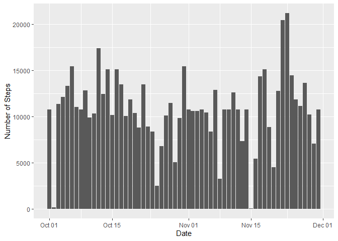

```r
dailyTotalSteps <- imputedActivityFrame %>% group_by(date) %>% summarize(totalSteps = sum(steps, na.rm = TRUE))
ggplot(dailyTotalSteps, aes(x = as.Date(date, format = "%y-%m-%d"), y = totalSteps)) +
  geom_bar(stat = "identity") +
  labs(x = "Date", y = "Number of Steps")
```

### Mean number of steps per day (imputed data)

```r
averageStepsPerDay <- mean(dailyTotalSteps$totalSteps)
print(averageStepsPerDay)
```

```
## [1] 10766.19
```

### Median number of steps per day (imputed data)

```r
medianStepsPerDay <- median(dailyTotalSteps$totalSteps)
print(medianStepsPerDay)
```

```
## [1] 10766.19
```

## Are there differences in activity patterns between weekdays and weekends?

### Create new factor variable for “weekend” or “weekday”

Let’s use the dataset that contains imputed values

```r
# create column with the weekdays to begin with
dayTypeSteps <- mutate(imputedActivityFrame, DayType = weekdays(date))
# set the day type as 'Weekend' or 'Weekday' depending on the day
dayTypeSteps$DayType[dayTypeSteps$DayType == "Saturday"] <- "Weekend"
dayTypeSteps$DayType[dayTypeSteps$DayType == "Sunday"] <- "Weekend"
dayTypeSteps$DayType[dayTypeSteps$DayType == "Monday"] <- "Weekday"
dayTypeSteps$DayType[dayTypeSteps$DayType == "Tuesday"] <- "Weekday"
dayTypeSteps$DayType[dayTypeSteps$DayType == "Wednesday"] <- "Weekday"
dayTypeSteps$DayType[dayTypeSteps$DayType == "Thursday"] <- "Weekday"
dayTypeSteps$DayType[dayTypeSteps$DayType == "Friday"] <- "Weekday"
# convert 'Weekend' and 'Weekday' to factors
dayTypeSteps$DayType <- as.factor(dayTypeSteps$DayType)
str(dayTypeSteps)
```

```
## 'data.frame':    17568 obs. of  4 variables:
##  $ steps   : num  1.717 0.3396 0.1321 0.1509 0.0755 ...
##  $ date    : Date, format: "2012-10-01" "2012-10-01" ...
##  $ interval: Factor w/ 288 levels "0","5","10","15",..: 1 2 3 4 5 6 7 8 9 10 ...
##  $ DayType : Factor w/ 2 levels "Weekday","Weekend": 1 1 1 1 1 1 1 1 1 1 ...
```

```r
head(dayTypeSteps)
```

```
##       steps       date interval DayType
## 1 1.7169811 2012-10-01        0 Weekday
## 2 0.3396226 2012-10-01        5 Weekday
## 3 0.1320755 2012-10-01       10 Weekday
## 4 0.1509434 2012-10-01       15 Weekday
## 5 0.0754717 2012-10-01       20 Weekday
## 6 2.0943396 2012-10-01       25 Weekday
```

### Daily average for Weekend and Weekday Plot

8. Panel plot comparing the average number of steps taken per 5-minute interval across weekdays and weekends

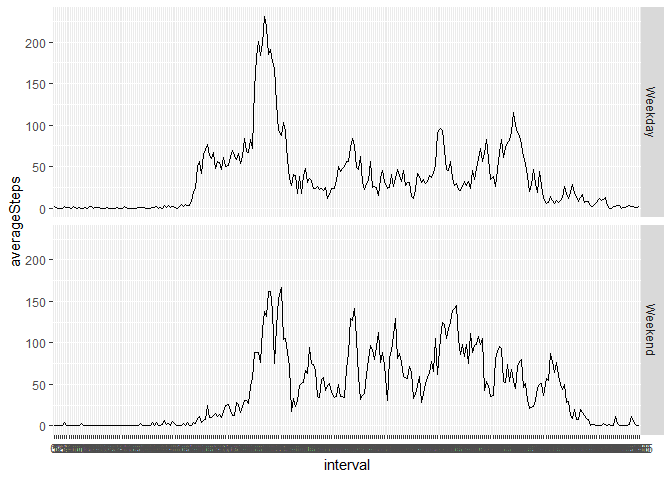

```r
intervalDayTypeSteps <- dayTypeSteps %>% group_by(interval, DayType) %>% summarize(averageSteps = mean(steps, na.rm = TRUE))
ggplot(intervalDayTypeSteps, aes(x = interval, y = averageSteps, group = DayType)) + geom_line() + facet_grid(DayType ~ .)
```